# Project Antoine-Jules

Packages and working directory :

```r
library(tidyverse)
library(knitr)
library(kableExtra)
library(broom)
library(here)
library(fixest)
library(haven)
library(dplyr)
library(ggplot2)
library(readxl)

setwd("/Users/antoineg./Desktop/R-bagilet")
```

# INTRODUCTION

This quarto document contains all the steps, information, plots and code relative to our simulation work related to the transfer capacity of electricity networks. It is divided in two respective sections, each divided into multiple sub-sections. The first part consists of observation on real data, and the second revolves around the interaction between our perfectly controlled *Data Generating Process* (DGP) and different models estimation. We also introduce a third part tackling the issue of effective sample.

# I - Observing real data

This first section consist on observing real data by importing open-data databases relative to prices, outages and flows in order to identify the distribution of those key variables. The importing part is heavy as it requires systematic cleaning.

## Importing data

Importation of “Flows data”. Flows represent power transfer between countries.

```r
flows1 <- read_csv("DONNEES_ELEC/Donnees France Espagne Physical flows/Cross-Border Physical Flow_202201010000-202301010000.csv")
flows2 <- read_csv("DONNEES_ELEC/Donnees France Espagne Physical flows/Cross-Border Physical Flow_202301010000-202401010000.csv")
flows3 <- read_csv("DONNEES_ELEC/Donnees France Espagne Physical flows/Cross-Border Physical Flow_202401010000-202501010000.csv")

flows_data <- rbind(flows1,flows2)
flows_data <- rbind(flows_data, flows3)

rm(flows1, flows2, flows3)
```

For the exercice purpose, we define the “date” variable that define for each 24 hours the day of the year.

```r
library("lubridate")

extract_date <- function(datetime_str) {
  date_str <- substr(datetime_str, 1, 10)
  dmy(date_str)
}


flows_data <- flows_data %>%
  mutate(date = extract_date(`Time (CET/CEST)`))

print(flows_data)



flows_data <- flows_data %>%
  mutate(
    date = as.Date(date),
    `BZN|ES > BZN|FR [MW]` = as.numeric(`BZN|ES > BZN|FR [MW]`),
    `BZN|FR > BZN|ES [MW]` = as.numeric(`BZN|FR > BZN|ES [MW]`)
  )

flows_parjour <- flows_data %>%
          group_by(date) %>%
          summarise(tot_spatofra = sum(`BZN|ES > BZN|FR [MW]`),
          tot_fratospa = sum(`BZN|FR > BZN|ES [MW]`))
```

Importation of “Outage data”. The outage database allow to observe the number of outage and the value of “NTC”, that is the net. transfer capacity. The raw database being dirty and large, an automatic cleaning process must be coded to simplify the data work.

```r
chemin_outage = "DONNEES_ELEC/Donnees France Espagne Outages"


fichiers_outage <- list.files(path = chemin_outage, pattern = "*.xlsx", full.names = TRUE)
liste_outage <- lapply(fichiers_outage, read_excel)
base_outage <- bind_rows(liste_outage)

base_outage <- base_outage %>%
  rename(Nature_outage = ...2, Period = ...3, In_Area = ...4, Out_Area = ...5, New_NTC = ...6)
base_outage <- base_outage %>%
  mutate(In_Area = sub("BZN\\|", "", In_Area), Out_Area = sub("BZN\\|", "", Out_Area))
base_outage <- base_outage |>
  mutate(
    VARY = ifelse(grepl("\\(VARY\\)", New_NTC), 1, 0),
    New_NTC = as.numeric(sub("\\s*\\(VARY\\)", "", New_NTC))
  )

base_outage <- base_outage[-1:-5,]
rm(liste_outage)
```

We also manipulate the hours to create a “day” variable :

```r
base_outage <- base_outage %>%
  mutate(date = extract_date(Period))

base_outage_day <- base_outage %>% group_by(date, In_Area, Out_Area) %>% summarise(New_NTC_day = mean(New_NTC, na.rm = TRUE), VARY_day = mean(VARY, na.rm = T))
```

Finally, we import price data.

```r
Day_ahead_Prices_2022_espagne <- read_csv("DONNEES_ELEC/Day-ahead Prices_2022_france.csv")
Day_ahead_Prices_2022_france <- read_csv("DONNEES_ELEC/Day-ahead Prices_2022_spain.csv")

Day_ahead_Prices_2022_espagne <- Day_ahead_Prices_2022_espagne %>% mutate(country = "ES")
Day_ahead_Prices_2022_espagne <- select(Day_ahead_Prices_2022_espagne, -c(3,4))
Day_ahead_Prices_2022_france <- Day_ahead_Prices_2022_france %>% mutate(country = "FR")
Day_ahead_Prices_2022_france <- select(Day_ahead_Prices_2022_france, -c(3,4))



Prices_base = rbind(Day_ahead_Prices_2022_espagne, Day_ahead_Prices_2022_france)
rm(Day_ahead_Prices_2022_espagne, Day_ahead_Prices_2022_france)


Prices_base <- Prices_base %>%
  mutate(date = extract_date(`MTU (CET/CEST)`))
Prices_base$date <- as.Date(Prices_base$date)
```

## Observe distributions in the data

### Daily data

In order for the data to be more tractable, we gather daily data into one “day database” :

```r
Prices_data_day <- Prices_base %>% group_by(date, country) %>% summarise(prix_moyen_jour = mean(`Day-ahead Price [EUR/MWh]`, na.rm = T ))


day_data <- left_join(flows_parjour, Prices_data_day)
day_data <- left_join(day_data, base_outage_day)
```

This yields NAs as the outage base is not defined other all entries (i.e there is no 1 to 1 mapping between days and outage). This is not a problem, as we can adjust the NA of the NTC column by choosing the max of the outflow between France and Spain.

```r
day_data$max_outage <- pmax(day_data$tot_spatofra, day_data$tot_fratospa, na.rm = TRUE)

day_data$New_NTC_day[is.na(day_data$New_NTC_day)] <- day_data$max_outage[is.na(day_data$New_NTC_day)]
```

We can now remove the other databases to keep a clean global environment.

```r
rm(base_outage_day, flows_parjour, Prices_data_day)
```

#### NTC distribution (days)

We plot the distribution of the key variables, starting by the NTC (Net. transfer capacity). The fitting curve is found purely “visually”, as no estimation method of the parameters is used in this document.

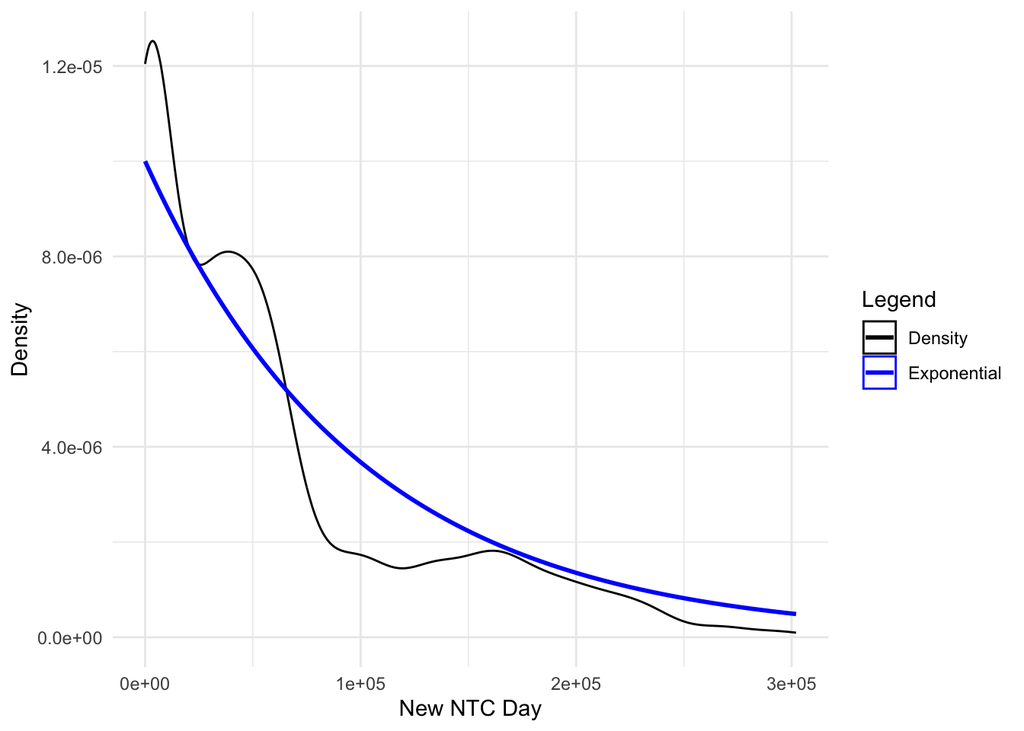

```r
ggplot(day_data, aes(x = New_NTC_day)) +
  geom_density(aes(color = "Density")) +
  stat_function(fun = function(x) dexp(x, rate = 0.00001, log = F), aes(color = "Exponential"), size = 1) +
  scale_color_manual(name = "Legend", values = c("Density" = "black", "Exponential" = "blue")) +
  labs(x = "New NTC Day", y = "Density") +
  theme_minimal()
```

The rate of this exponential distribution is very small (which translates into a quite high expected value). The exponential distribution can be explained as the New NTC variable is generated by a random process being the outage per hour, with the number of hours between two outage following a Poisson distribution.

#### Prices distribution (days)

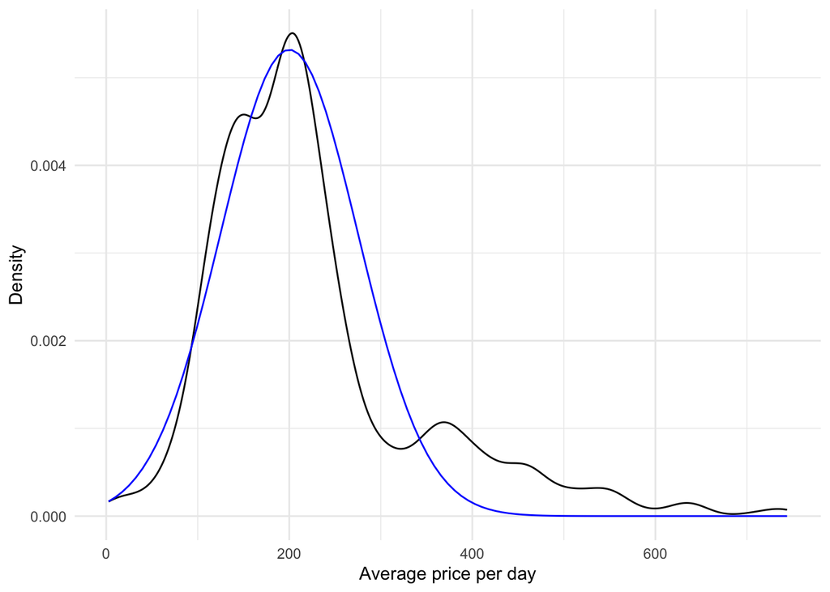

```r
ggplot(day_data, aes(x = prix_moyen_jour)) +
  geom_density() +
  stat_function(fun = function(x) dnorm(x, mean = 200, sd = 75), color = "blue") +
   labs(x = "Average price per day", y = "Density") +
   theme_minimal()
```

### Hourly data

Now we take a look at the distribution of variables not in days but in hours, and see how the increase in the number of observations modify those distribution. Intuitively, the previous normal distribution should stay normal (yet with different mean/standard deviation)

#### NTC distribution (Hours)

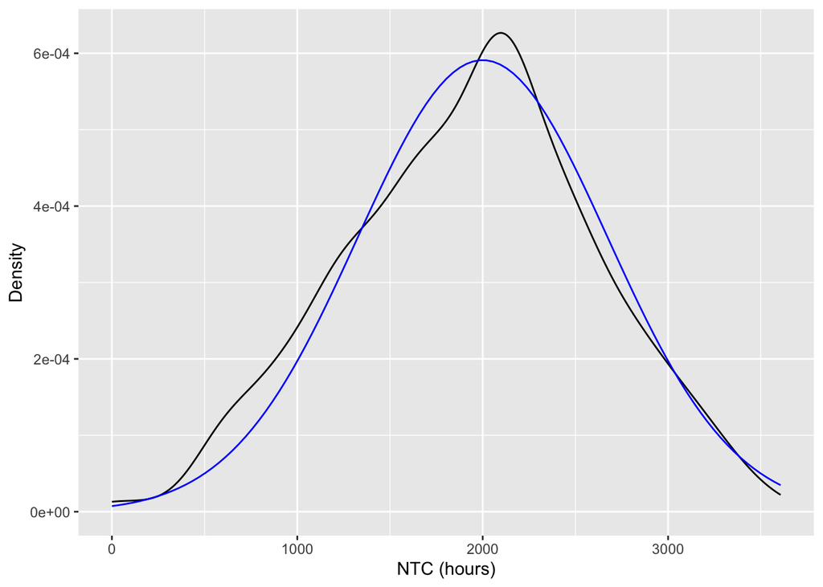

```r
base_outage %>%
  ggplot(aes(x = New_NTC)) +
  geom_density() +
  stat_function(fun = dnorm, args = list(mean = 2000, sd = 675), color = "blue") +
  labs(
    x = "NTC (hours)",
    y = "Density"
  )
```

We observe a shift from the exponential to a normal distribution. it would actually require further investigation (behind the scope of this document), but this can possibly be explained as the changing from days to hours could be analogous to summing an exponential process each hours, such that the sum of the exponential distribution yields a “Exponential Normal Distribution”.

#### Price distribution (Hours)

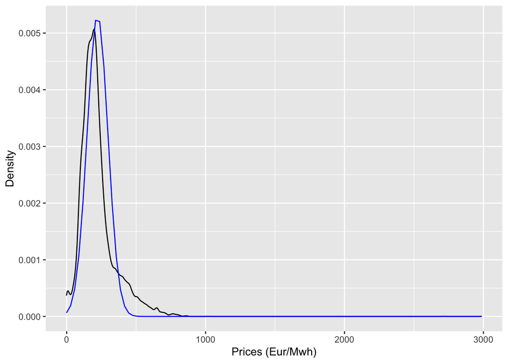

```r
Prices_base %>%
  ggplot(aes(x = `Day-ahead Price [EUR/MWh]`)) +
  geom_density() +
  stat_function(fun = dnorm, args = list(mean = 222, sd = 75), color ="blue") +
  labs(x = "Prices (Eur/Mwh)",
       y = "Density")
```

# II - Data generating process : modeling endogeneity.

The general goal of this part is to observe how a wrong model (i.e a model that does not capture the DGP) behave when changing the number of observations, the characterizations, the choice of fixed-effect. We want to see how far the estimated effect is from the true effect, in other words, to see if not taking account endogeneity yields completely wrong point-estimate, or if they are decently acceptable.

## Simulating daily data.

We create a function data generating process that will be the basis for all the later simulations. We start by simulating the simplest form (i.e with daily data) : the DGP, the formation of prices, is linearly determined using a a linear function of controls, NTC and an error. However, the *TRUE* process is not a function of only NTC, but also of prices. We thus model an endogenous/circular relationship of the general form $p = controls + NewNTC(NTC,p) + error$ .

```r
generate_data <- function(date,
                          country,
                          beta_0,
                          gamma_0,
                          gamma_1,
                          beta_1,
                          beta_2,
                          sigma_control,
                          sigma_epsilon,
                          sigma_prices)
{
  individuals <- 1:country
  date <- 1:date
  panel <- crossing(individuals, date)

  n <- nrow(panel)

  panel <- panel %>%
    mutate(
      control = rnorm(n, 0, sigma_control),
      NTC = rexp(n, 0.00001),
      epsilon = rnorm(n, 0, sigma_epsilon),
      prices = rnorm(n, 200, sigma_prices)
    )

  panel <- panel %>%
    mutate(
      new_NTC = gamma_0 + gamma_1 * prices + NTC,
      prices = beta_0 + beta_1 * control + beta_2 * new_NTC + epsilon
    )

  return(panel)
}
```

We define a set of parameters based on the previous observations of real data.

```r
param_set1 <- tibble(date = 365,
                country = 2,
                beta_0 = 30,
                gamma_0 = 10,
                gamma_1 = 0.0025,
                beta_1 = 0.05,
                beta_2 = 0.01,
                sigma_control = 1,
                sigma_epsilon = 1,
                sigma_prices = 75)
```

Repeat 400 times the model (the 400 threshold is define arbitrarily, but should guarantee a smooth distribution) :

```r
day_reg <- function(data) {
  feols(prices ~ control + NTC, data = data,
        panel.id = c("date", "individuals"),
        fixef = c("date", "individuals"))  |>
    summary() |>
    broom::tidy(conf.int = TRUE, conf.level = 0.95)
}

day_sim_auto <- function(...) {
  generate_data(...) %>%
    day_reg() %>%
    cbind(as_tibble(list(...)))
}


param_set1 %>% pmap(day_sim_auto) %>% list_rbind()

n_iter <- 400

sim_day <- param_set1 %>% uncount(n_iter)
sim_day_res <- sim_day %>% pmap(day_sim_auto) %>% list_rbind()
```

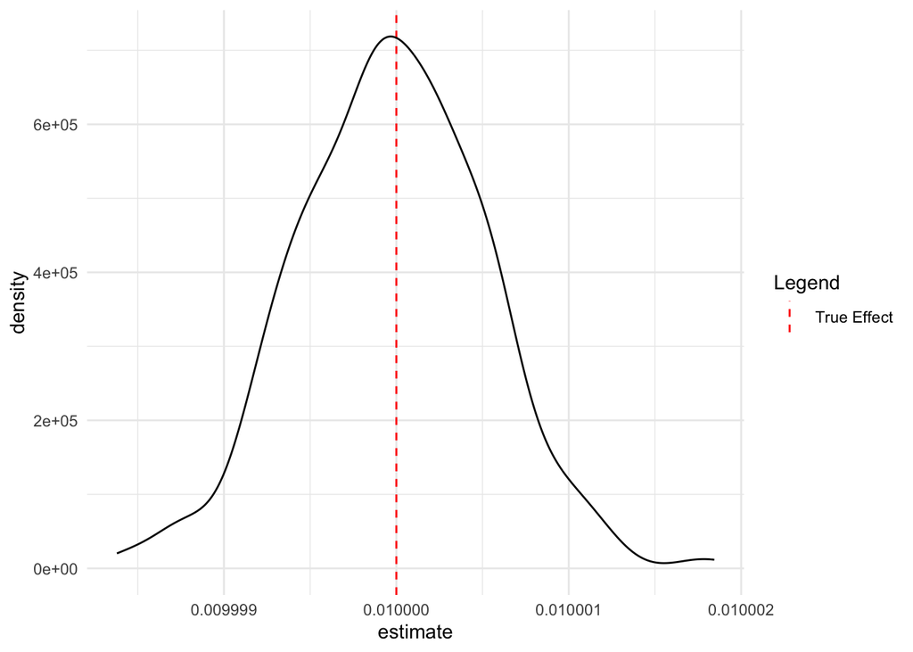

```r
sim_day_res %>%
filter(term == "NTC") %>%
ggplot(aes(x = estimate)) +
  geom_vline(aes(xintercept = 0.01, color = "True Effect"), linetype = "dashed") +
  geom_density() +
  scale_color_manual(name = "Legend", values = c("True Effect" = "red")) +
  theme_minimal()
```

- First, even wrong, our model capture par of the variation of new_NTC.
- The simple DGP. In fact, this is linked to the first point, the simpler the DGP, the easier, even for a wrong model to capture a bit of it.
- The true effect is small, thus the distance is also small. Yet in relative terms, it may be in fact higher.

## Simulating hourly data.

We define another DGP based on the values of hourly data : we thus inflate the number of observations. This code “basis” will allow to construct more complex DGP later on.

```r
generate_data_hours <- function(date,
                          country,
                          beta_0,
                          gamma_0,
                          gamma_1,
                          beta_1,
                          beta_2,
                          sigma_control,
                          sigma_NTC,
                          sigma_epsilon,
                          sigma_prices)
{
  individuals <- 1:country
  date <- 1:date
  panel <- crossing(individuals, date)

  n <- nrow(panel)

  panel <- panel %>%
    mutate(
      control = rnorm(n, 0, sigma_control),
      NTC = rnorm(n, 2000, sigma_NTC),
      epsilon = rnorm(n, 0, sigma_epsilon),
      prices = rnorm(n, 200, sigma_prices)
    )

  panel <- panel %>%
    mutate(
      NTC_new = gamma_0 + gamma_1 * prices + NTC,
      prices = beta_0 + beta_1 * control + beta_2 * NTC_new + epsilon
    )

  return(panel)
}
```

We define another set of parameters :

```r
param_set2 <- tibble(date = 8760,
                     country = 2,
                     beta_0 = 30,
                     gamma_0 = 10,
                     gamma_1 = 0.0025,
                     beta_1 = 0.05,
                     beta_2 = 0.01,
                     sigma_NTC = 675,
                     sigma_control = 1,
                     sigma_epsilon = 1,
                     sigma_prices = 126.4)
```

Then, we run a similar kind of code to repeat 400 times the model.

```r
hours_reg <- function(data) {
  feols(prices ~ control + NTC, data = data,
        panel.id = c("date", "individuals"),
        fixef = c("date", "individuals"))  %>%
    summary() %>%
    broom::tidy(conf.int = TRUE, conf.level = 0.95)
}

hours_sim_auto <- function(...) {
  generate_data_hours(...) %>%
    hours_reg() %>%
    cbind(as_tibble(list(...)))
}


param_set2 %>% pmap(hours_sim_auto) %>% list_rbind()

n_iter <- 400

sim_hours <- param_set2 %>% uncount(n_iter)
sim_hours_res <- sim_hours %>% pmap(hours_sim_auto) %>% list_rbind()
```

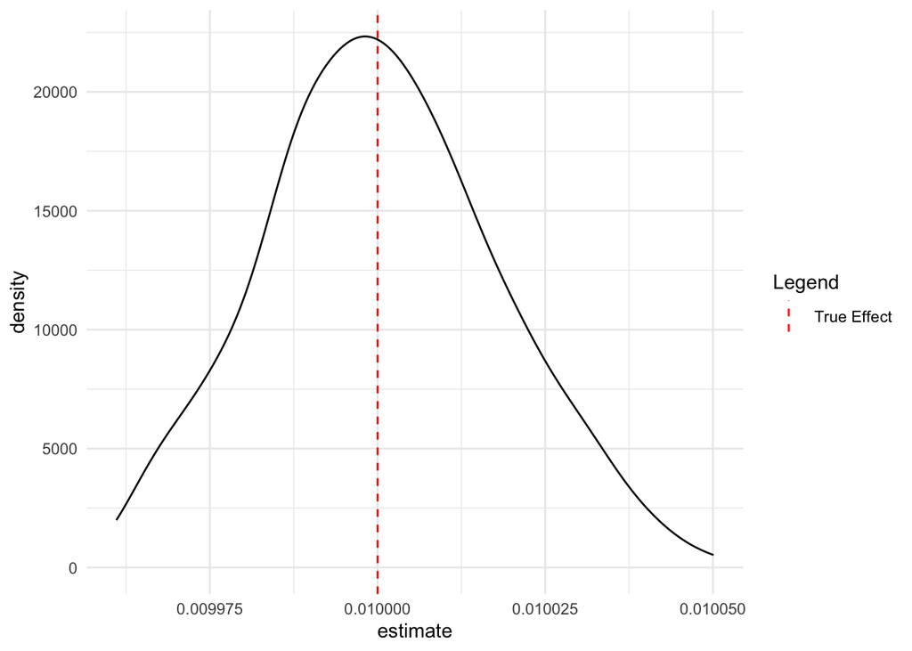

```r
sim_hours_res %>%
filter(term == "NTC") %>%
ggplot(aes(x = estimate)) +
  geom_vline(aes(xintercept = 0.01, color = "True Effect"), linetype = "dashed") +
  geom_density() +
  scale_color_manual(name = "Legend", values = c("True Effect" = "red")) +
  theme_minimal()
```

## Adding complexity to the DGP

We keep working with hourly data in order to work with larger dimension data.

### Differentiating the controls

In this section we observe how splitting the controls into two distinct distribution with respect to countries would affect the wrong model. In order to model this, we again change the DGP. In the following chunk, we directly define the parameter set number 3. We also directly run the simulation ;

```r
param_set3 <- tibble(
  date = 8760,
  country = 2,
  beta_0 = 30,
  gamma_0 = 10,
  gamma_1 = 0.0025,
  beta_1_country1 = 0.05,
  beta_1_country2 = 0.07,
  beta_2 = 0.01,
  sigma_NTC = 675,
  sigma_control1 = 1,
  sigma_control2 = 1.5,
  sigma_epsilon = 1,
  sigma_prices = 126.4
)

# Fonction pour générer les données
generate_data_hours_differentcontrols <- function(date,
                                                  country,
                                                  beta_0,
                                                  gamma_0,
                                                  gamma_1,
                                                  beta_1_country1,
                                                  beta_1_country2,
                                                  beta_2,
                                                  sigma_control1,
                                                  sigma_control2,
                                                  sigma_NTC,
                                                  sigma_epsilon,
                                                  sigma_prices) {
  individuals <- 1:country
  date <- 1:date
  panel <- crossing(individuals, date)

  n <- nrow(panel)

  panel <- panel %>%
    mutate(
      control1 = rnorm(n, 0, sigma_control1),
      control2 = rnorm(n, 0, sigma_control2),
      NTC = rnorm(n, 2000, sigma_NTC),
      epsilon = rnorm(n, 0, sigma_epsilon),
      prices = rnorm(n, 200, sigma_prices)
    )

  panel <- panel %>%
    mutate(
      new_NTC = gamma_0 + gamma_1 * prices + NTC,
      prices = beta_0 +
        case_when(
          individuals <= country / 2 ~ beta_1_country1 * control1,
          TRUE ~ beta_1_country2 * control2
        ) + beta_2 * new_NTC + epsilon
    )

  return(panel)
}



hours_reg <- function(data) {
  feols(prices ~ control1 + control2 + NTC, data = data,
        panel.id = c("date", "individuals"),
        fixef = c("date", "individuals"))  |>
    summary() |>
    broom::tidy(conf.int = TRUE, conf.level = 0.95)
}


hours_sim_auto <- function(...) {
  generate_data_hours_differentcontrols(...) %>%
    hours_reg() %>%
    cbind(as_tibble(list(...)))
}


param_set3 %>% pmap(hours_sim_auto) %>% list_rbind()


n_iter <- 400


sim_hours <- param_set3 %>% uncount(n_iter)
sim_hours_res_control <- sim_hours %>% pmap(hours_sim_auto) %>% list_rbind()
```

Now plotting the distribution, as before.

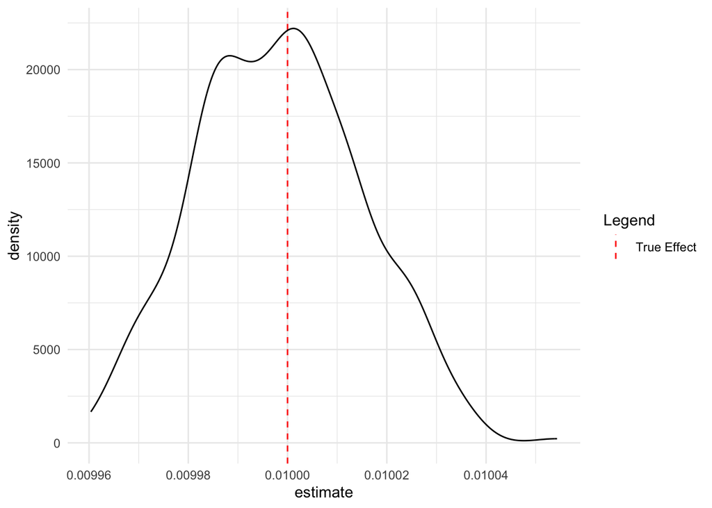

```r
sim_hours_res_control %>%
filter(term == "NTC") %>%
ggplot(aes(x = estimate)) +
  geom_vline(aes(xintercept = 0.01, color = "True Effect"), linetype = "dashed") +
  geom_density() +
  scale_color_manual(name = "Legend", values = c("True Effect" = "red")) +
  theme_minimal()
```

### Adding (some kind of) seasonality

First, we model seasonality by a dummy variable “cold/hot” that takes the value 1 in autumn and winter, and 0 in spring and summer. However this sensitivity differ with respect to countries, thus we distinguish two types of estimates. It is indeed very reasonable to assume the variation of prices is time dependent, as we observe an increase in demand in cold seasons. We can write the DGP as following :

```r
generate_data_hours_froid <- function(date,
                                      country,
                                      beta_0,
                                      gamma_0,
                                      gamma_1,
                                      beta_1_country1,
                                      beta_1_country2,
                                      beta_2,
                                      sigma_control1,
                                      sigma_control2,
                                      sigma_NTC,
                                      sigma_epsilon,
                                      sigma_prices,
                                      beta_froid_country1,
                                      beta_froid_country2) {
  individuals <- 1:country
  date <- 1:date
  panel <- crossing(individuals, date)

  n <- nrow(panel)

  panel <- panel %>%
    mutate(
      control1 = rnorm(n, 0, sigma_control1),
      control2 = rnorm(n, 0, sigma_control2),
      NTC = rnorm(n, 2000, sigma_NTC),
      epsilon = rnorm(n, 0, sigma_epsilon),
      prices = rnorm(n, 200, sigma_prices),
      month = (date - 1) %/% 730 + 1
    )

  panel <- panel %>%
    mutate(
      froid = case_when(
        month %in% 11:12 | month %in% 1:4 ~ 1,
        TRUE ~ 0
      ),
      new_NTC = gamma_0 + gamma_1 * prices + NTC,
      prices = beta_0 +
        case_when(
          individuals <= country / 2 ~ beta_1_country1 * control1 + beta_froid_country1 * froid,
          TRUE ~ beta_1_country2 * control2 + beta_froid_country2 * froid
        ) + beta_2 * new_NTC + epsilon
    )

  return(panel)
}


param_set4 <- tibble(
  date = 8760,
  country = 2,
  beta_0 = 30,
  gamma_0 = 10,
  gamma_1 = 0.0025,
  beta_1_country1 = 0.05,
  beta_1_country2 = 0.07,
  beta_2 = 0.01,
  sigma_control1 = 1,
  sigma_control2 = 1.5,
  sigma_NTC = 675,
  sigma_epsilon = 1,
  sigma_prices = 126.4,
  beta_froid_country1 = 25,
  beta_froid_country2 = 50
)


hours_reg_froid <- function(data) {
  feols(prices ~ control1 + control2 + NTC + froid, data = data,
        panel.id = c("individuals"),
        fixef = c("individuals"))  |>
    summary() |>
    broom::tidy(conf.int = TRUE, conf.level = 0.95)
}


hours_sim_auto_froid <- function(...) {
  generate_data_hours_froid(...) %>%
    hours_reg_froid() %>%
    cbind(as_tibble(list(...)))
}

param_set4 %>% pmap(hours_sim_auto_froid) %>% list_rbind()


n_iter <- 400

sim_hours_froid <- param_set4 %>% uncount(n_iter)
sim_hours_froid_res <- sim_hours_froid %>% pmap(hours_sim_auto_froid) %>% list_rbind()
```

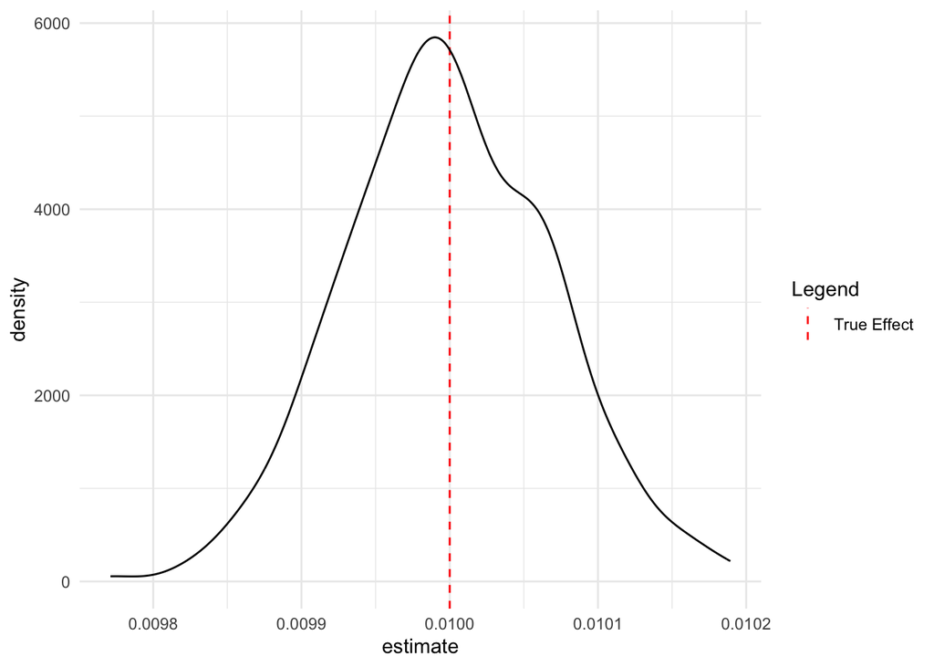

```r
sim_hours_froid_res %>%
filter(term == "NTC") %>%
ggplot(aes(x = estimate)) +
  geom_vline(aes(xintercept = 0.01, color = "True Effect"), linetype = "dashed") +
  geom_density() +
  scale_color_manual(name = "Legend", values = c("True Effect" = "red")) +
  theme_minimal()
```

Now do some cleaning of the environment as it becomes saturated. We do this mainly for readability, but in the case of working with larger dataset, it can easily saturate the RAM.

```r
rm(base_outage, day_data, flows_data, NTC_hours_estimate_froid, Prices_base, sim_day, sim_hours, sim_hours_froid)
```

Bonus- computing some power :

```r
power <- function(data, term, alpha = 0.05) {
  data %>%
    mutate(signif = (p.value < alpha)) %>%
    filter(term == term) %>%
    summarise(power = mean(signif))
}


# Calculer la puissance pour chaque dataset
power_res1 <- power(sim_day_res, "NTC")
power_res2 <- power(sim_hours_res, "NTC")
power_res3 <- power(sim_hours_res_control, "NTC")
power_res4 <- power(sim_hours_froid_res, "NTC")

# Afficher les résultats
print(power_res1)
```

```
  power
1  0.59
```

```r
print(power_res2)
```

```
    power
1 0.99625
```

```r
print(power_res3)
```

```
      power
1 0.8691667
```

```r
print(power_res4)
```

```
  power
1  0.25
```

A simple DGP with a high number observations drastically increase the power of the model. However, it does not take into account all the interactions of the true dataset.

### Adding a random shock

We use the latest DGP, closer to what the “natural” price determination would be : a function of both controls that differ across country and a sensitivity that also differs according to the individual. For added complexity, we model an exogenous random shock that strongly affect the price, but with low probability.

```r
generate_data_hours_5 <- function(date,
                                      country,
                                      beta_0,
                                      gamma_0,
                                      gamma_1,
                                      beta_1_country1,
                                      beta_1_country2,
                                      beta_2,
                                      beta_3,
                                      sigma_control1,
                                      sigma_control2,
                                      sigma_NTC,
                                      sigma_epsilon,
                                      sigma_prices,
                                      beta_froid_country1,
                                      beta_froid_country2) {
  individuals <- 1:country
  date <- 1:date
  panel <- crossing(individuals, date)

  n <- nrow(panel)

  panel <- panel %>%
    mutate(
      control1 = rnorm(n, 0, sigma_control1),
      control2 = rnorm(n, 0, sigma_control2),
      NTC = rnorm(n, 2000, sigma_NTC),
      shock = rbernoulli(n, p = 0.01),
      epsilon = rnorm(n, 0, sigma_epsilon),
      prices = rnorm(n, 200, sigma_prices),
      hours = (date - 1) %/% 730 + 1,
      month = (date - 1) %/% 30 + 1,
    )

  panel <- panel %>%
    mutate(
      froid = case_when(
        month %in% 11:12 | month %in% 1:4 ~ 1,
        TRUE ~ 0
      ),
      new_NTC = gamma_0 + gamma_1 * prices + NTC,
      prices = beta_0 +
        case_when(
          individuals <= country / 2 ~ beta_1_country1 * control1 + beta_froid_country1 * froid,
          TRUE ~ beta_1_country2 * control2 + beta_froid_country2 * froid
        ) + beta_2 * new_NTC + beta_3*shock + epsilon
    )

  return(panel)
}
```

Defining a new set of parameters :

```r
param_set5 <- tibble(
  date = 8760,
  country = 2,
  beta_0 = 30,
  gamma_0 = 10,
  gamma_1 = 0.0025,
  beta_1_country1 = 0.05,
  beta_1_country2 = 0.07,
  beta_2 = 0.01,
  beta_3 = 40,
  sigma_control1 = 1,
  sigma_control2 = 1.5,
  sigma_NTC = 675,
  sigma_epsilon = 1,
  sigma_prices = 126.4,
  beta_froid_country1 = 25,
  beta_froid_country2 = 50
)
```

```r
hours_reg_5 <- function(data) {
  feols(prices ~ control1 + control2 + NTC + froid, data = data,
        panel.id = c("individuals"),
        fixef = c("individuals"))  |>
    summary() |>
    broom::tidy(conf.int = TRUE, conf.level = 0.95)
}


hours_sim_auto_5 <- function(...) {
  generate_data_hours_5(...) %>%
    hours_reg_5() %>%
    cbind(as_tibble(list(...)))
}

param_set5 %>% pmap(hours_sim_auto_5) %>% list_rbind()


n_iter <- 400

sim_hours_5 <- param_set5 %>% uncount(n_iter)
sim_hours_5_res <- sim_hours_5 %>% pmap(hours_sim_auto_5) %>% list_rbind()
```

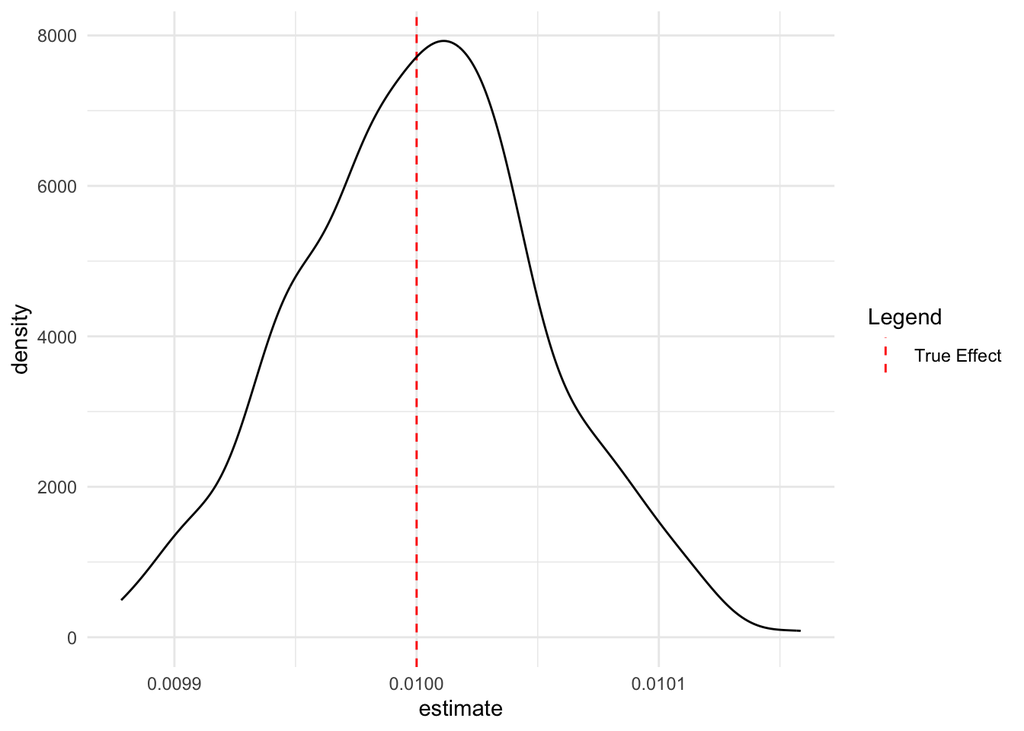

```r
sim_hours_5_res %>%
  filter(term == "NTC") %>%
  ggplot(aes(x = estimate)) +
  geom_vline(aes(xintercept = 0.01, color = "True Effect"), linetype = "dashed") +
  geom_density() +
  scale_color_manual(name = "Legend", values = c("True Effect" = "red")) +
  theme_minimal()
```

The results are very similar to what what we previously modeled.

### BONUS SIMULATION : A simple binary logit model on an outage dummy.

In this section, we simulate a very simple model that measure the probability of having to bear the cost of maintenance as a function of the network capacity, the objective quality of the network and a random harsh weather components. Very basically, we have to estimate :

$P(\text{maintenance}) = \frac{1}{1 + e^{-(\text{coef\_capacity} \cdot \text{capacity} + \text{coef\_quality} \cdot \text{quality} + \text{coef\_weather} \cdot \text{weather} + \text{intercept})}}$

We change a bit the structure of the code, as we will differentiate each parameter with respect to countries. The values of the coefficients are purely hypothetical, and used for the sole purpose of the example and the code template.

```r
coef_capacity <- -0.05
coef_quality <- 0.05
coef_weather <- 0.3
intercept <- -1.0


hours_in_year <- 8760

country1_capacity <- 50  # Network capacity for Country 1
country2_capacity <- 70  # Network capacity for Country 2

country1_quality <- 60  # Objective quality for Country 1
country2_quality <- 80  # Objective quality for Country 2


country1_weather <- rnorm(hours_in_year, mean = 0, sd = 1)
country2_weather <- rnorm(hours_in_year, mean = 0, sd = 1)


prob_maintenance <- function(capacity, quality, weather, coef_capacity, coef_quality, coef_weather, intercept) {
  1 / (1 + exp(-(coef_capacity * capacity + coef_quality * quality + coef_weather * weather + intercept)))
}


country1_probabilities <- sapply(1:hours_in_year, function(hour) {
  prob_maintenance(country1_capacity, country1_quality, country1_weather[hour], coef_capacity, coef_quality, coef_weather, intercept)
})

country2_probabilities <- sapply(1:hours_in_year, function(hour) {
  prob_maintenance(country2_capacity, country2_quality, country2_weather[hour], coef_capacity, coef_quality, coef_weather, intercept)
})


prob_df <- data.frame(
  Hour = rep(1:hours_in_year, 2),
  Country = rep(c("Country 1", "Country 2"), each = hours_in_year),
  Probability = c(country1_probabilities, country2_probabilities)
)
```

Plotting the results :

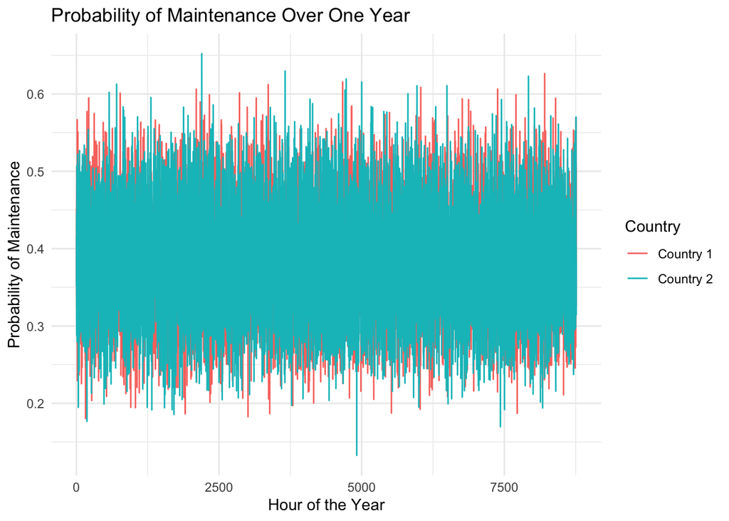

```r
ggplot(prob_df, aes(x = Hour, y = Probability, color = Country)) +
  geom_line() +
  labs(title = "Probability of Maintenance Over One Year",
       x = "Hour of the Year",
       y = "Probability of Maintenance") +
  theme_minimal()
```

## III- Effective sample analysis

The following function simulates and estimates a linear model, and then analyzes the impact of varying an exogenous variable on the standard error of the explanatory variable.

The model we choose to estimate incorporates an explaining variable which is defined by it’s mean and it’s variance, and a control part :

```r
country <- function(
    gamma = 0.6,          #
    size_outages = 50, # mean of explaining variable
    var_due_outages = 25,  #variance of explaining variable
    beta_0 = 30,       # intercept
    beta_1 = 0.1,     # True effect
    beta_2 = 0.5,      # Control effect
    n_obs = 10000
) # Defining the main parameters
{

  residuals <- rnorm(n = n_obs, mean = 10, sd = 5)
  controls <- runif(n = n_obs, min = 10, max = 100)
  exp <- rnorm(n = n_obs, mean = size_outages, sd = var_due_outages)
  corr_var <- gamma * controls
  explaining_var <- exp + corr_var

  # Create the dataset
  data_sim <- data.frame(
    controls = controls,
    exp = exp,
    corr_var = corr_var,
    explaining_var = explaining_var,
    residuals = residuals
  )

  # Generate the dependent variable : DATA GENERATING PROCESS
  data_sim$Y <- beta_0 + beta_1 * data_sim$explaining_var +
    beta_2 * data_sim$controls + data_sim$residuals

  # Estimate the model :
  reg_model <- lm(Y ~ explaining_var + controls, data = data_sim)
  reg_summary <- summary(reg_model)

  # Extract main statistics
  results <- list(
    coefficients = reg_summary$coefficients,
    r_squared = reg_summary$r.squared,
    adj_r_squared = reg_summary$adj.r.squared,
    f_statistic = reg_summary$fstatistic,
    data = data_sim,
    model = reg_model
  )


  se_explaining_var <- summary(reg_model)$coefficients["explaining_var", "Std. Error"]



  return(se_explaining_var)
}

# Example usage
results <- country(
  gamma = 0.6,
  size_outages = 50,
  var_due_outages = 25
)
```

```r
# Create the vector of size_outages values
var_outages_values <- seq(from = 10, to = 40, by = 0.25)

# Create the dataset: vary the size of outages, i.e., the exogenous part of the explanatory variable
# to observe its effect on the precision of the estimators
se_results <- data.frame(
  var_due_outages = var_outages_values,
  standard_error = sapply(var_outages_values, function(x) {
    country(size_outages = x)
  })
)
```

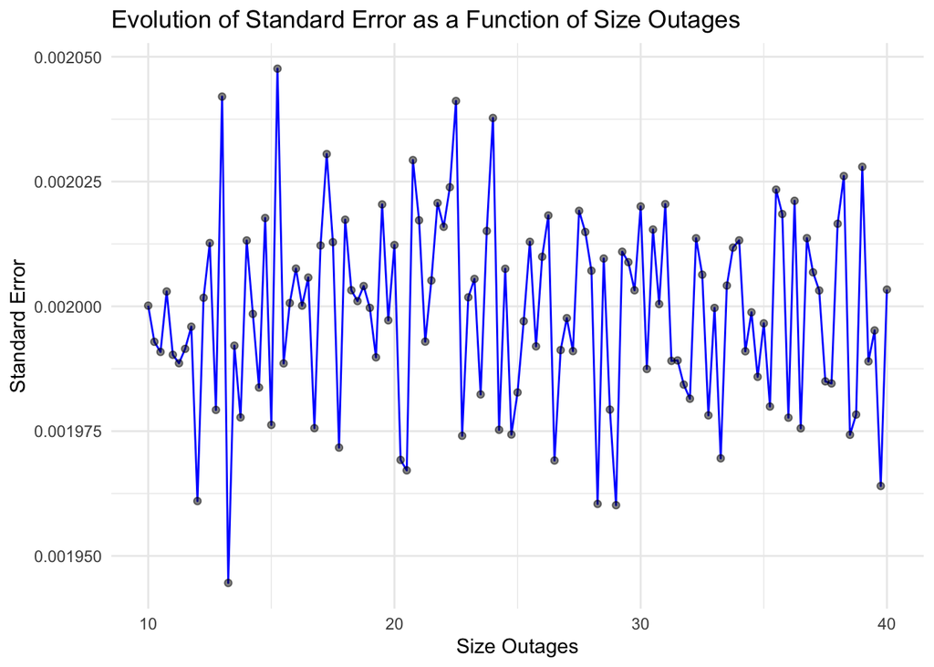

```r
# Visualize the relationship with ggplot2
library(ggplot2)
ggplot(se_results, aes(x = var_due_outages, y = standard_error)) +
  geom_line(color = "blue") +
  geom_point(alpha = 0.5) +
  theme_minimal() +
  labs(
    title = "Evolution of Standard Error as a Function of Size Outages",
    x = "Size Outages",
    y = "Standard Error"
  )
```